BACHARELADO EM CIÊNCIAS BIOLÓGICAS

# 1 Introdução

Em 2019, a Comissão Propria de Avaliação (CPA) da Universidade Federal Rural de Pernambuco (UFRPE) realizou a autoavaliação institucional referente aos seguintes eixos avaliativos: Planejamento e Avaliação Institucional e Desenvolvimento Institucional.

Esta avaliação foi feita a partir de questionários online, disponibilizados de forma voluntária aos discentes, docentes e técnicos da instituição, no período de 23 de abril a 29 de julho de 2019. Maiores detalhes sobre a metodologia de autoavaliação podem ser encontrados no 2º Relatório Parcial de Autoavaliação Institucional (ANO-BASE 2019), disponível no site da [CPA/UFRPE](http://cpa.ufrpe.br/br/relatorio-de-autoavaliacao-institucional/).

Este relatório apresenta as respostas dos discentes, separadas por curso. Como docentes e técnicos não são vinculados a cursos, e sim a unidades, departamentos ou orgãos, as suas respostas não estão contempladas neste relatório de cursos.

Note que este relatório apresenta os resultados da avaliação da UFRPE *como um todo* sob o ponto de vista dos estudantes deste curso; sendo assim, não pode ser interpretado como uma avaliação do curso propriamente dito.

# 2 Participação

Este curso contava com 293 discentes aptos a participar desta avaliação, dos quais 77 (26.28%) responderam ao questionário. Foram utilizados os resultados absolutos de participação, sem análise estatística. Como a participação em alguns cursos foi baixa, essas respostas podem não representar a realidade, apresentando apenas um indicador de como os discentes avaliaram esses eixos.

Do total das respostas obtidas para os itens dos dois eixos avaliados, 0.38% foram avaliados como “péssimo”, 2.06% foram avaliados como “ruim”, 9.78% como “regular”, 35.45% como “bom”, 34.22% foram considerados “excelente”, e 18.11% foram outras opções de resposta.

# 3 Maiores médias

Lista das 5 perguntas com respostas mais positivas, com base na média ponderada das respostas dos discentes deste curso, considerando ambos os eixos avaliativos.

[output not shown]

# 4 Menores médias

Lista das 5 perguntas com respostas mais negativas, com base na média ponderada das respostas dos discentes deste curso, considerando ambos os eixos avaliativos.

| Item | Média |
| --- | --- |
| Avalie o seu conhecimento sobre o Plano de Desenvolvimento Institucional | 7.0 |
| Avalie a utilização dos resultados da autoavaliação institucional no planejamento do seu Curso | 7.1 |
| Avalie as ações de planejamento no seu curso | 7.2 |
| Avalie a atuação da UFRPE na promoção da produção artística | 7.4 |
| Avalie o acesso aos relatórios de autoavaliação da UFRPE | 7.5 |

# 5 Panorama (perguntas selecionadas)

Esta seção contém gráficos com os resultados da avaliação de alguns itens pré-selecionados: Ações de Planejamento de Cursos e Utilização dos Resultados da Autoavaliação Institucional no Planejamento de Cursos, além da atuação da UFRPE na promoção do desenvolvimento econômico e social, da sustentabilidade, da igualdade étnico-racial, e na valorização da diversidade.

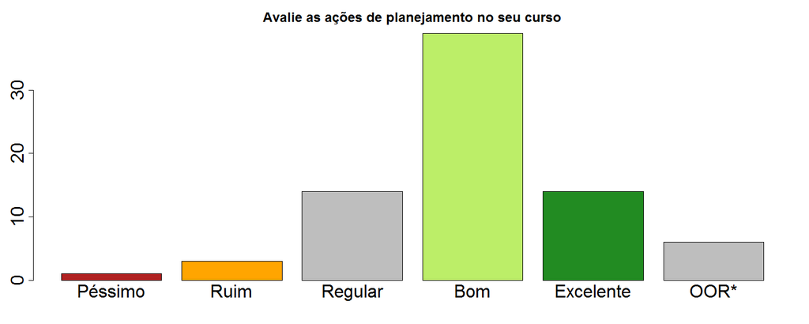

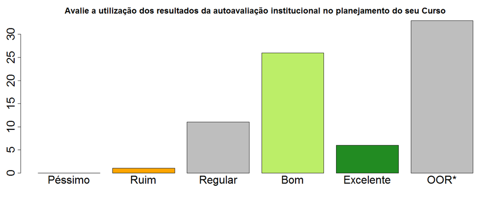

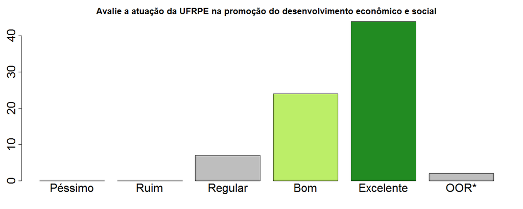

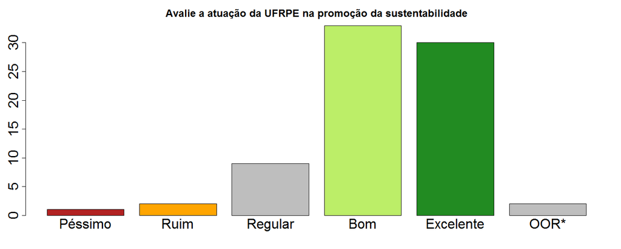

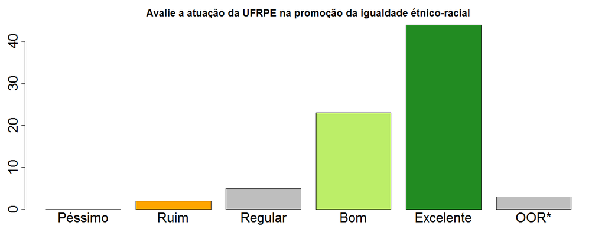

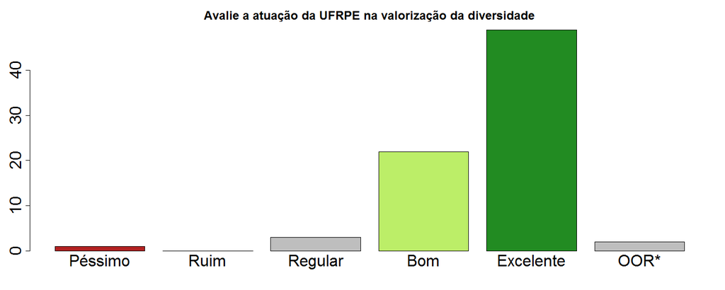

*OOR: Outras opções de resposta

# 6 Resultado completo (discentes)

[output not shown]

*OOR: Outras opções de resposta